# Election Prep

Author

Elizabeth Mastilak

## Set Up

Start by loading packages and data:

```r
library(tidyverse)
voters_sos <-
  read_csv("data/registered voters/voters_SOS/voters_SOS.csv")
```

I don’t love the way the Secretary of State classifies party affiliation. So I will be making two graphs for each type of graph: one with the SoS party affiliations and one with my own definitions.

Is it perfect? No.

That’s why I will be making every graph with the SoS definition too. This will provide a sense of standardization.

```r
voters_sos <- voters_sos %>%
  mutate(party = NA) %>%
  mutate(
    party = ifelse(!is.na(PARTY_AFFILIATION),
                   PARTY_AFFILIATION,
                   case_when(
                     (`PRIMARY.03/19/2024` == "R") |
                       (`PRIMARY.03/19/2024` == "o" & `PRIMARY.03/17/2020` == "R") |
                       (`PRIMARY.03/19/2024` == "o" & `PRIMARY.03/17/2020` == "o" &
                          `PRIMARY.03/15/2016` == "R") ~ "R",

                     (`PRIMARY.03/19/2024` == "D") |
                       (`PRIMARY.03/19/2024` == "o" & `PRIMARY.03/17/2020` == "D") |
                       (`PRIMARY.03/19/2024` == "o" & `PRIMARY.03/17/2020` == "o" &
                          `PRIMARY.03/15/2016` == "D") ~ "D",

                     TRUE ~ party  # Retain existing value if no condition is met
                   )
    )
  ) %>%
  mutate(party = ifelse(is.na(party),
                        "U",
                        party))
```

```r
voters_sos <- voters_sos %>%
  mutate(PARTY_AFFILIATION = ifelse(is.na(PARTY_AFFILIATION),
                        "U",
                        PARTY_AFFILIATION))
```

A little bit of comparison between my definition and the SoS definition:

```r
table(voters_sos$party)
```

```
     D      R      U
128447 124725 350877
```

```r
table(voters_sos$PARTY_AFFILIATION)
```

```
     D      R      U
 58840  71856 473353
```

## Graphs with SoS Definition

Let’s prepare the data to examine the ages of voters for each political party.

```r
ages_summary <- voters_sos %>%
  filter(AGE < 111) %>%
  group_by(AGE, PARTY_AFFILIATION) %>%
  summarise(count = n()) %>%
  ungroup()
```

Now let’s look at the age distribution for all registered voters by political party.

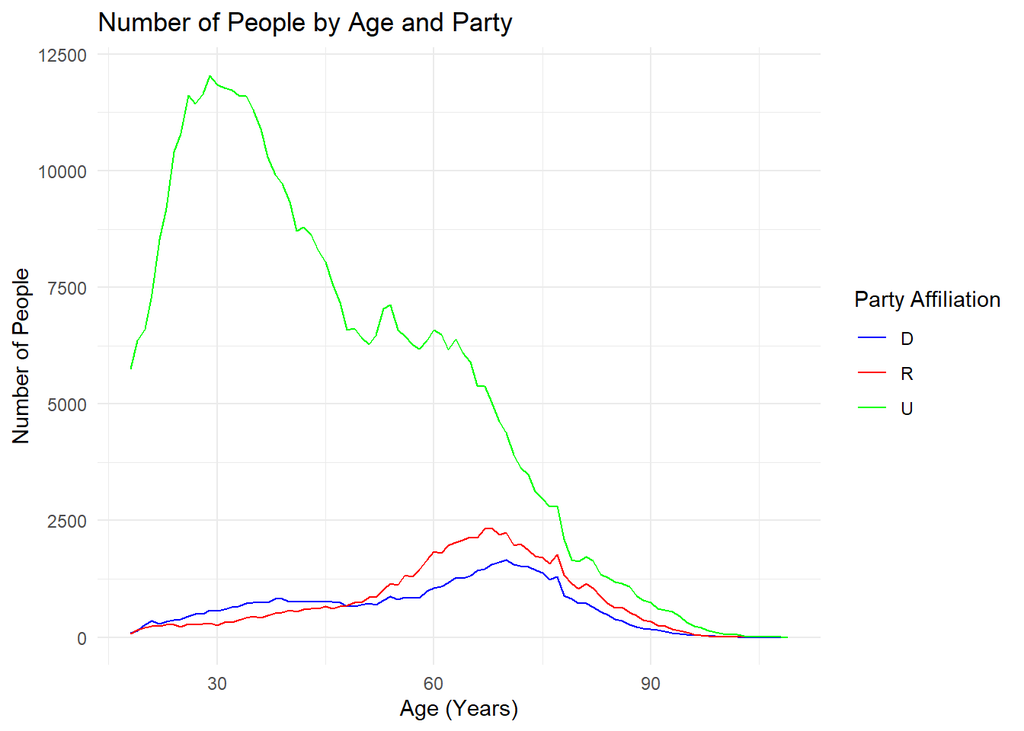

```r
ages_summary %>%
  ggplot(aes(x = AGE, y = count, color = PARTY_AFFILIATION)) +
  geom_line() +
  scale_color_manual(values = c("D" = "blue", "R" = "red", "U" = "green")) +
  labs(title = "Number of People by Age and Party",
       x = "Age (Years)",
       y = "Number of People",
       color = "Party Affiliation") +
  theme_minimal()
```

Now each one separate:

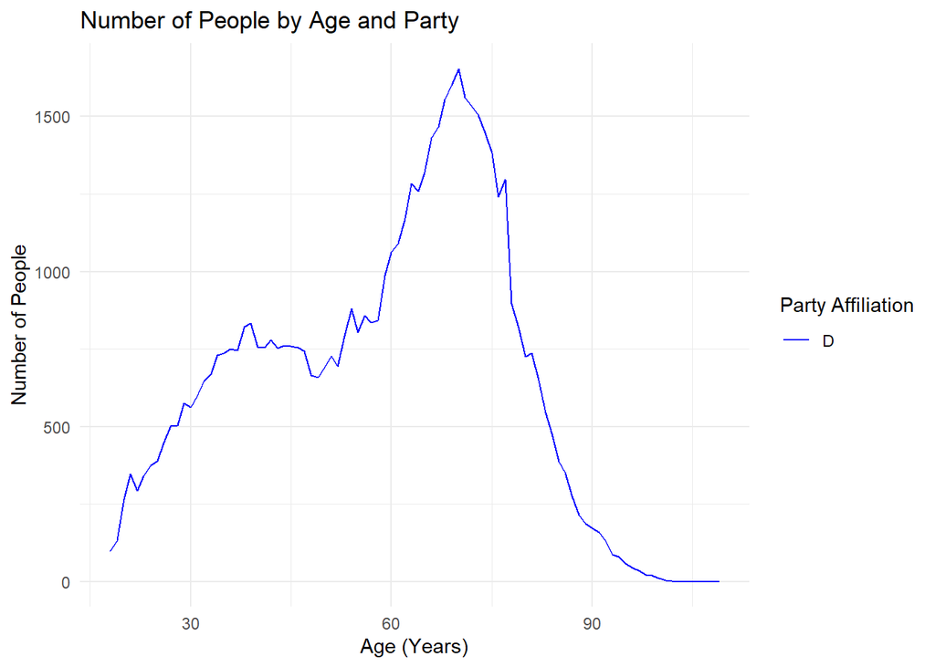

```r
ages_summary %>%
  filter(PARTY_AFFILIATION == "D") %>%
  ggplot(aes(x = AGE, y = count, color = PARTY_AFFILIATION)) +
  geom_line() +
  scale_color_manual(values = c("D" = "blue", "R" = "red", "U" = "green")) +
  labs(title = "Number of People by Age and Party",
       x = "Age (Years)",
       y = "Number of People",
       color = "Party Affiliation") +
  theme_minimal()
```

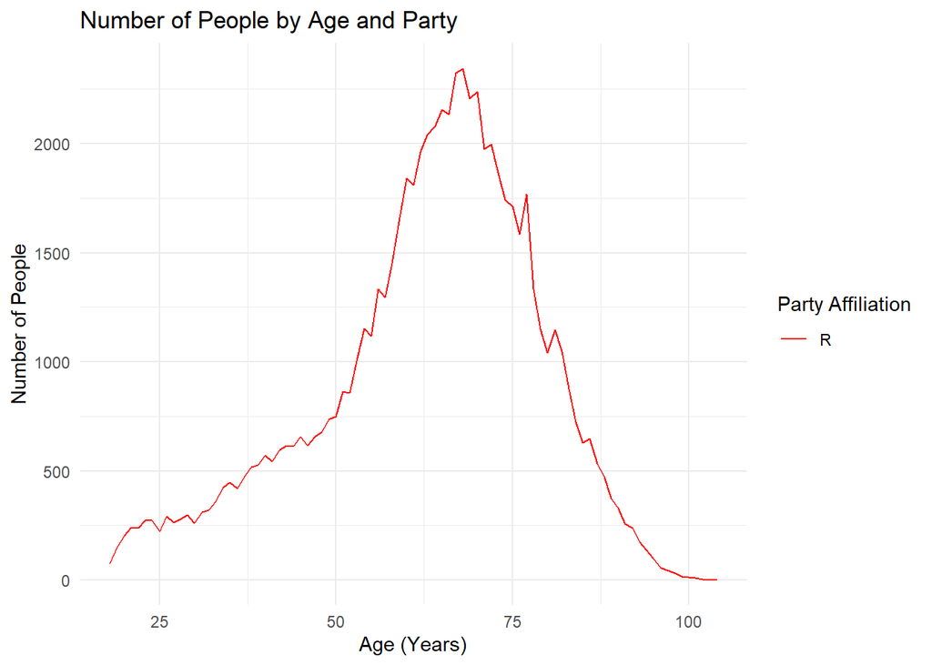

```r
ages_summary %>%
  filter(PARTY_AFFILIATION == "R") %>%
  ggplot(aes(x = AGE, y = count, color = PARTY_AFFILIATION)) +
  geom_line() +
  scale_color_manual(values = c("D" = "blue", "R" = "red", "U" = "green")) +
  labs(title = "Number of People by Age and Party",
       x = "Age (Years)",
       y = "Number of People",
       color = "Party Affiliation") +
  theme_minimal()
```

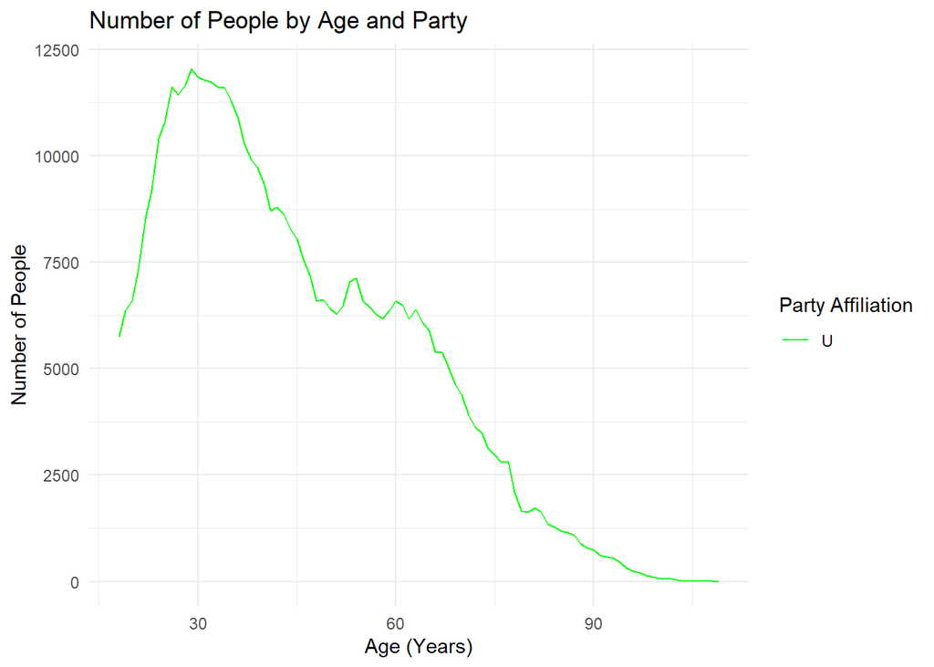

```r
ages_summary %>%
  filter(PARTY_AFFILIATION == "U") %>%
  ggplot(aes(x = AGE, y = count, color = PARTY_AFFILIATION)) +
  geom_line() +
  scale_color_manual(values = c("D" = "blue", "R" = "red", "U" = "green")) +
  labs(title = "Number of People by Age and Party",
       x = "Age (Years)",
       y = "Number of People",
       color = "Party Affiliation") +
  theme_minimal()
```

Now some combinations:

- D vs R
- D vs U
- R vs U

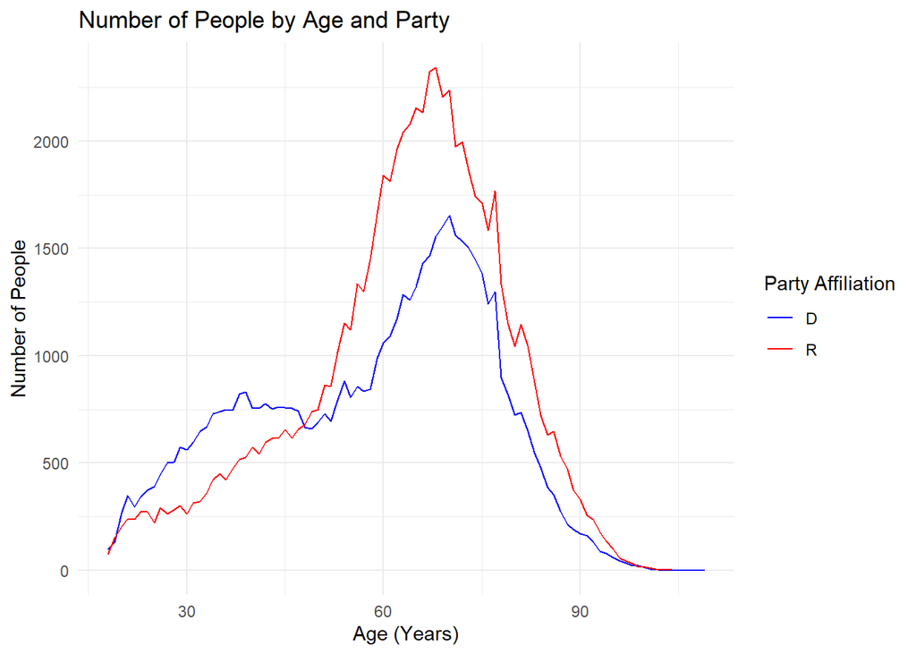

```r
ages_summary %>%
  filter(PARTY_AFFILIATION != "U") %>%
  ggplot(aes(x = AGE, y = count, color = PARTY_AFFILIATION)) +
  geom_line() +
  scale_color_manual(values = c("D" = "blue", "R" = "red", "U" = "green")) +
  labs(title = "Number of People by Age and Party",
       x = "Age (Years)",
       y = "Number of People",
       color = "Party Affiliation") +
  theme_minimal()
```

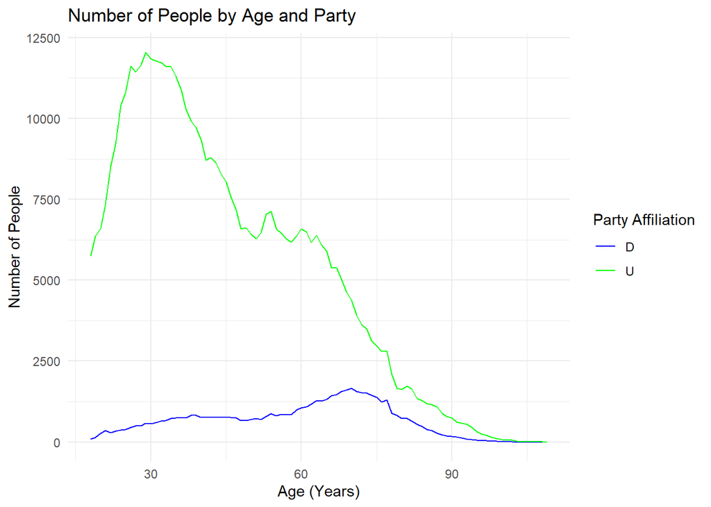

```r
ages_summary %>%
  filter(PARTY_AFFILIATION != "R") %>%
  ggplot(aes(x = AGE, y = count, color = PARTY_AFFILIATION)) +
  geom_line() +
  scale_color_manual(values = c("D" = "blue", "R" = "red", "U" = "green")) +
  labs(title = "Number of People by Age and Party",
       x = "Age (Years)",
       y = "Number of People",
       color = "Party Affiliation") +
  theme_minimal()
```

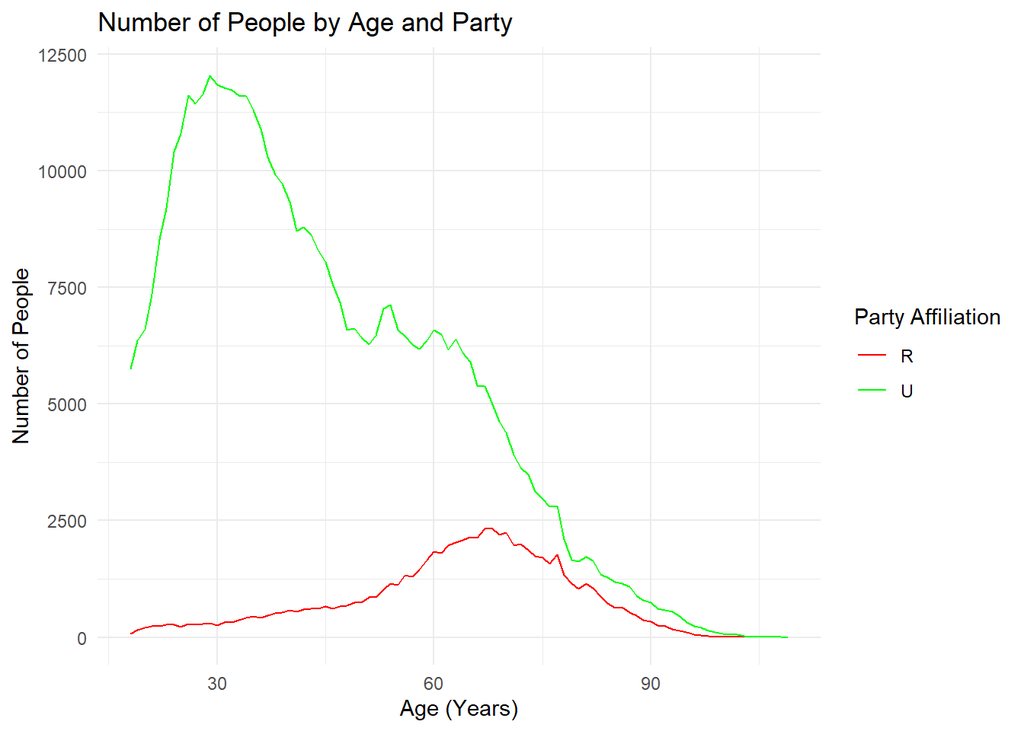

```r
ages_summary %>%
  filter(PARTY_AFFILIATION != "D") %>%
  ggplot(aes(x = AGE, y = count, color = PARTY_AFFILIATION)) +
  geom_line() +
  scale_color_manual(values = c("D" = "blue", "R" = "red", "U" = "green")) +
  labs(title = "Number of People by Age and Party",
       x = "Age (Years)",
       y = "Number of People",
       color = "Party Affiliation") +
  theme_minimal()
```

## Graphs with My Definition

Now let’s examine the distributions with a bit of a different definition.

```r
age_summary <- voters_sos %>%
  filter(AGE < 111) %>%
  group_by(AGE, party) %>%
  summarise(count = n()) %>%
  ungroup()
```

The complete graph:

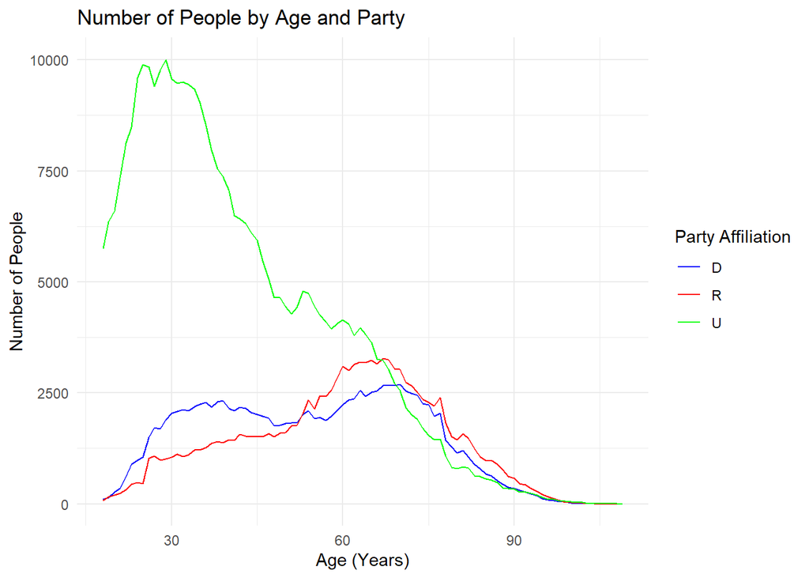

```r
age_summary %>%
  ggplot(aes(x = AGE, y = count, color = party)) +
  geom_line() +
  scale_color_manual(values = c("D" = "blue", "R" = "red", "U" = "green")) +
  labs(title = "Number of People by Age and Party",
       x = "Age (Years)",
       y = "Number of People",
       color = "Party Affiliation") +
  theme_minimal()
```

By each group:

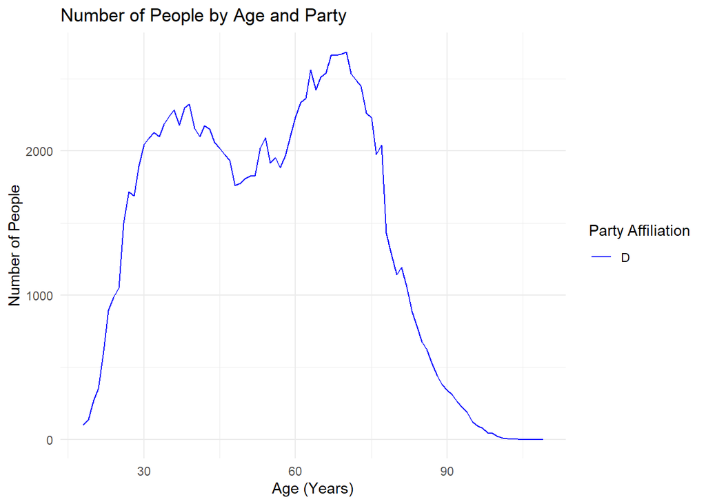

```r
age_summary %>%
  filter(party == "D") %>%
  ggplot(aes(x = AGE, y = count, color = party)) +
  geom_line() +
  scale_color_manual(values = c("D" = "blue", "R" = "red", "U" = "green")) +
  labs(title = "Number of People by Age and Party",
       x = "Age (Years)",
       y = "Number of People",
       color = "Party Affiliation") +
  theme_minimal()
```

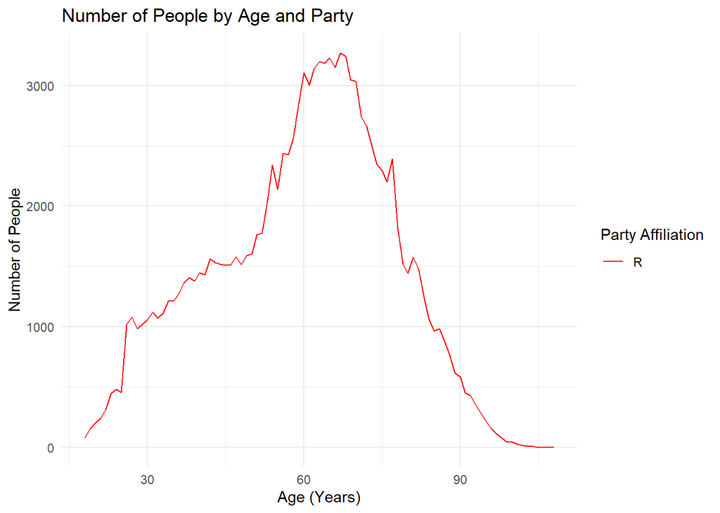

```r
age_summary %>%
  filter(party == "R") %>%
  ggplot(aes(x = AGE, y = count, color = party)) +
  geom_line() +
  scale_color_manual(values = c("D" = "blue", "R" = "red", "U" = "green")) +
  labs(title = "Number of People by Age and Party",
       x = "Age (Years)",
       y = "Number of People",
       color = "Party Affiliation") +
  theme_minimal()
```

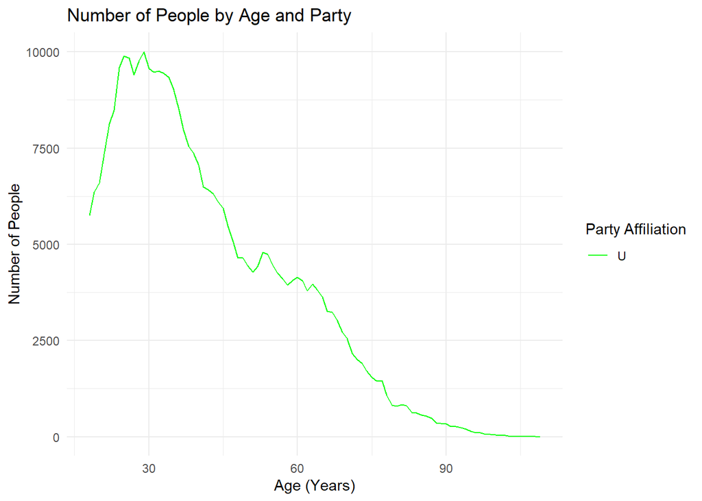

```r
age_summary %>%
  filter(party == "U") %>%
  ggplot(aes(x = AGE, y = count, color = party)) +
  geom_line() +
  scale_color_manual(values = c("D" = "blue", "R" = "red", "U" = "green")) +
  labs(title = "Number of People by Age and Party",
       x = "Age (Years)",
       y = "Number of People",
       color = "Party Affiliation") +
  theme_minimal()
```

Now some combinations:

- D vs R
- D vs U
- R vs U

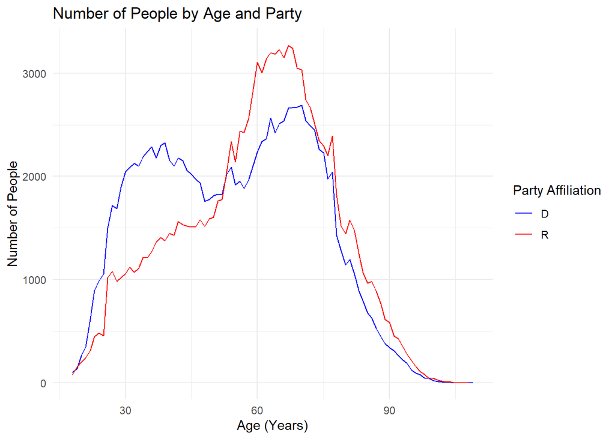

```r
age_summary %>%
  filter(party != "U") %>%
  ggplot(aes(x = AGE, y = count, color = party)) +
  geom_line() +
  scale_color_manual(values = c("D" = "blue", "R" = "red", "U" = "green")) +
  labs(title = "Number of People by Age and Party",
       x = "Age (Years)",
       y = "Number of People",
       color = "Party Affiliation") +
  theme_minimal()
```

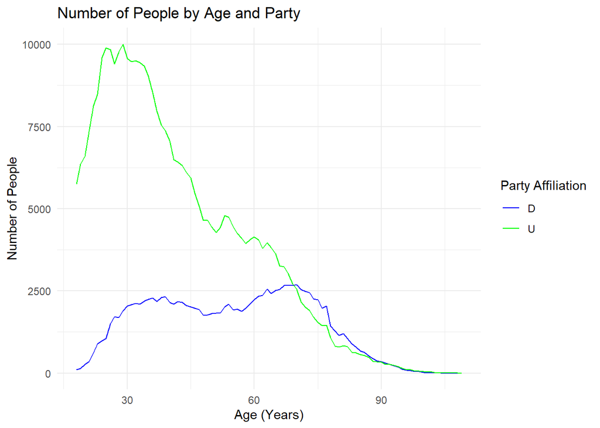

```r
age_summary %>%
  filter(party != "R") %>%
  ggplot(aes(x = AGE, y = count, color = party)) +
  geom_line() +
  scale_color_manual(values = c("D" = "blue", "R" = "red", "U" = "green")) +
  labs(title = "Number of People by Age and Party",
       x = "Age (Years)",
       y = "Number of People",
       color = "Party Affiliation") +
  theme_minimal()
```

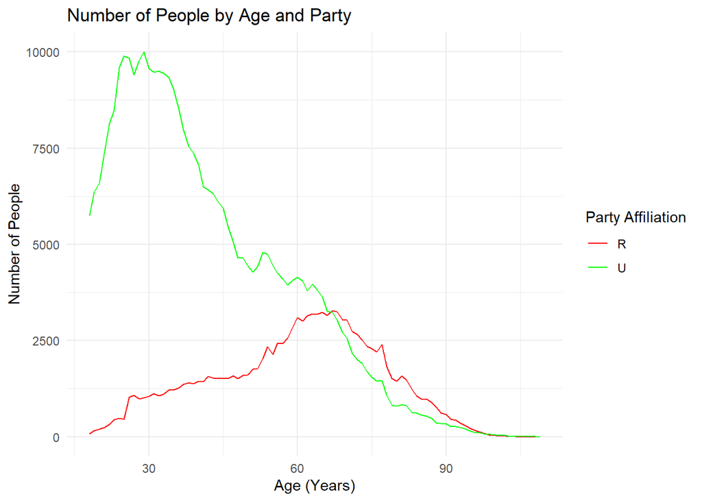

```r
age_summary %>%
  filter(party != "D") %>%
  ggplot(aes(x = AGE, y = count, color = party)) +
  geom_line() +
  scale_color_manual(values = c("D" = "blue", "R" = "red", "U" = "green")) +
  labs(title = "Number of People by Age and Party",
       x = "Age (Years)",
       y = "Number of People",
       color = "Party Affiliation") +
  theme_minimal()
```